# Лабораторна робота №1. Підготовка даних

```python
#імпортуємо бібліотеки NumPy, pandas та Matplotlib
import pandas as pd
import numpy as np
import matplotlib.pyplot as plt
%matplotlib inline
```

**1. Визначаємо типи ознак та їх допустимих значень.**

- age: continuous.
- workclass: Private, Self-emp-not-inc, Self-emp-inc, Federal-gov, Local-gov, State-gov, Without-pay, Never-worked.
- fnlwgt: continuous.
- education: Bachelors, Some-college, 11th, HS-grad, Prof-school, Assoc-acdm, Assoc-voc, 9th, 7th-8th, 12th, Masters, 1st-4th, 10th, Doctorate, 5th-6th, Preschool.
- education-num: continuous.
- marital-status: Married-civ-spouse, Divorced, Never-married, Separated, Widowed, Married-spouse-absent, Married-AF-spouse.
- occupation: Tech-support, Craft-repair, Other-service, Sales, Exec-managerial, Prof-specialty, Handlers-cleaners, Machine-op-inspct, Adm-clerical, Farming-fishing, Transport-moving, Priv-house-serv, Protective-serv, Armed-Forces.
- relationship: Wife, Own-child, Husband, Not-in-family, Other-relative, Unmarried.
- race: White, Asian-Pac-Islander, Amer-Indian-Eskimo, Other, Black.
- sex: Female, Male.
- capital-gain: continuous.
- capital-loss: continuous.
- hours-per-week: continuous.
- native-country: United-States, Cambodia, England, Puerto-Rico, Canada, Germany, Outlying-US(Guam-USVI-etc), India, Japan, Greece, South, China, Cuba, Iran, Honduras, Philippines, Italy, Poland, Jamaica, Vietnam, Mexico, Portugal, Ireland, France, Dominican-Republic, Laos, Ecuador, Taiwan, Haiti, Columbia, Hungary, Guatemala, Nicaragua, Scotland, Thailand, Yugoslavia, El-Salvador, Trinadad&Tobago, Peru, Hong, Holand-Netherlands.
- gross-income: >50K, <=50K.

**2. Завантажуємо набір даних у DataFrame і перевіряємо на відсутність помилок (виводимо кількість рядків та стовпців, а також значення типів стовпців).**

```python
df_adult = pd.read_csv('adult.data', header=None) #зчитування файлу
df_adult.index = df_adult.index + 1 #індекси починаються з 1
df_adult.head(10) #виведення перших 10 рядків
```

|  | 0 | 1 | 2 | 3 | 4 | 5 | 6 | 7 | 8 | 9 | 10 | 11 | 12 | 13 | 14 |
| --- | --- | --- | --- | --- | --- | --- | --- | --- | --- | --- | --- | --- | --- | --- | --- |
| 1 | 39 | State-gov | 77516 | Bachelors | 13 | Never-married | Adm-clerical | Not-in-family | White | Male | 2174 | 0 | 40 | United-States | <=50K |
| 2 | 50 | Self-emp-not-inc | 83311 | Bachelors | 13 | Married-civ-spouse | Exec-managerial | Husband | White | Male | 0 | 0 | 13 | United-States | <=50K |
| 3 | 38 | Private | 215646 | HS-grad | 9 | Divorced | Handlers-cleaners | Not-in-family | White | Male | 0 | 0 | 40 | United-States | <=50K |
| 4 | 53 | Private | 234721 | 11th | 7 | Married-civ-spouse | Handlers-cleaners | Husband | Black | Male | 0 | 0 | 40 | United-States | <=50K |
| 5 | 28 | Private | 338409 | Bachelors | 13 | Married-civ-spouse | Prof-specialty | Wife | Black | Female | 0 | 0 | 40 | Cuba | <=50K |
| 6 | 37 | Private | 284582 | Masters | 14 | Married-civ-spouse | Exec-managerial | Wife | White | Female | 0 | 0 | 40 | United-States | <=50K |
| 7 | 49 | Private | 160187 | 9th | 5 | Married-spouse-absent | Other-service | Not-in-family | Black | Female | 0 | 0 | 16 | Jamaica | <=50K |
| 8 | 52 | Self-emp-not-inc | 209642 | HS-grad | 9 | Married-civ-spouse | Exec-managerial | Husband | White | Male | 0 | 0 | 45 | United-States | >50K |
| 9 | 31 | Private | 45781 | Masters | 14 | Never-married | Prof-specialty | Not-in-family | White | Female | 14084 | 0 | 50 | United-States | >50K |
| 10 | 42 | Private | 159449 | Bachelors | 13 | Married-civ-spouse | Exec-managerial | Husband | White | Male | 5178 | 0 | 40 | United-States | >50K |

```python
df_adult.shape #виведення кількості рядків та стовпців
```

```
(32561, 15)
```

```python
df_adult.info() #виведення інформації про типи даних рядків
```

```
<class 'pandas.core.frame.DataFrame'>
RangeIndex: 32561 entries, 1 to 32561
Data columns (total 15 columns):
 #   Column  Non-Null Count  Dtype
---  ------  --------------  -----
 0   0       32561 non-null  int64
 1   1       32561 non-null  object
 2   2       32561 non-null  int64
 3   3       32561 non-null  object
 4   4       32561 non-null  int64
 5   5       32561 non-null  object
 6   6       32561 non-null  object
 7   7       32561 non-null  object
 8   8       32561 non-null  object
 9   9       32561 non-null  object
 10  10      32561 non-null  int64
 11  11      32561 non-null  int64
 12  12      32561 non-null  int64
 13  13      32561 non-null  object
 14  14      32561 non-null  object
dtypes: int64(6), object(9)
memory usage: 3.7+ MB
```

**3. Програмне встановлюємо назви стовпців DataFrame з опису набору даних.**

```python
#налаштування стовпців набору даних та його виведення
df_adult.columns = ['Age', 'Workclass', 'Fnlwgt', 'Education', 'Education_num',
                    'Marital_status', 'Occupation', 'Relationship', 'Race', 'Sex',
                    'Capital_gain', 'Capital_loss', 'Hours_per_week', 'Native_country', 'Gross_income']
df_adult
```

|  | Age | Workclass | Fnlwgt | Education | Education_num | Marital_status | Occupation | Relationship | Race | Sex | Capital_gain | Capital_loss | Hours_per_week | Native_country | Gross_income |
| --- | --- | --- | --- | --- | --- | --- | --- | --- | --- | --- | --- | --- | --- | --- | --- |
| 1 | 39 | State-gov | 77516 | Bachelors | 13 | Never-married | Adm-clerical | Not-in-family | White | Male | 2174 | 0 | 40 | United-States | <=50K |
| 2 | 50 | Self-emp-not-inc | 83311 | Bachelors | 13 | Married-civ-spouse | Exec-managerial | Husband | White | Male | 0 | 0 | 13 | United-States | <=50K |
| 3 | 38 | Private | 215646 | HS-grad | 9 | Divorced | Handlers-cleaners | Not-in-family | White | Male | 0 | 0 | 40 | United-States | <=50K |
| 4 | 53 | Private | 234721 | 11th | 7 | Married-civ-spouse | Handlers-cleaners | Husband | Black | Male | 0 | 0 | 40 | United-States | <=50K |
| 5 | 28 | Private | 338409 | Bachelors | 13 | Married-civ-spouse | Prof-specialty | Wife | Black | Female | 0 | 0 | 40 | Cuba | <=50K |
| ... | ... | ... | ... | ... | ... | ... | ... | ... | ... | ... | ... | ... | ... | ... | ... |
| 32557 | 27 | Private | 257302 | Assoc-acdm | 12 | Married-civ-spouse | Tech-support | Wife | White | Female | 0 | 0 | 38 | United-States | <=50K |
| 32558 | 40 | Private | 154374 | HS-grad | 9 | Married-civ-spouse | Machine-op-inspct | Husband | White | Male | 0 | 0 | 40 | United-States | >50K |
| 32559 | 58 | Private | 151910 | HS-grad | 9 | Widowed | Adm-clerical | Unmarried | White | Female | 0 | 0 | 40 | United-States | <=50K |
| 32560 | 22 | Private | 201490 | HS-grad | 9 | Never-married | Adm-clerical | Own-child | White | Male | 0 | 0 | 20 | United-States | <=50K |
| 32561 | 52 | Self-emp-inc | 287927 | HS-grad | 9 | Married-civ-spouse | Exec-managerial | Wife | White | Female | 15024 | 0 | 40 | United-States | >50K |

32561 rows × 15 columns

**4. Виводимо таблиці з основними характеристиками кожної ознаки (для кількісних ознак – мінімум, максимум, середнє, середньоквадратичне відхилення, 1-й, 2-й та 3-й квартилі; для якісних – кількість унікальних значень, частота кожного унікального значення).**

**Кількісні значення:**

```python
df_adult.describe()
```

|  | Age | Fnlwgt | Education_num | Capital_gain | Capital_loss | Hours_per_week |
| --- | --- | --- | --- | --- | --- | --- |
| count | 32561.000000 | 3.256100e+04 | 32561.000000 | 32561.000000 | 32561.000000 | 32561.000000 |
| mean | 38.581647 | 1.897784e+05 | 10.080679 | 1077.648844 | 87.303830 | 40.437456 |
| std | 13.640433 | 1.055500e+05 | 2.572720 | 7385.292085 | 402.960219 | 12.347429 |
| min | 17.000000 | 1.228500e+04 | 1.000000 | 0.000000 | 0.000000 | 1.000000 |
| 25% | 28.000000 | 1.178270e+05 | 9.000000 | 0.000000 | 0.000000 | 40.000000 |
| 50% | 37.000000 | 1.783560e+05 | 10.000000 | 0.000000 | 0.000000 | 40.000000 |
| 75% | 48.000000 | 2.370510e+05 | 12.000000 | 0.000000 | 0.000000 | 45.000000 |
| max | 90.000000 | 1.484705e+06 | 16.000000 | 99999.000000 | 4356.000000 | 99.000000 |

**Якісні ознаки:**

```python
df_adult['Workclass'].nunique() #кількість унікальних значень ряду даних Workclass
```

```
9
```

```python
df_adult['Workclass'].value_counts() #частота унікальних значень ряду даних Workclass
```

```
 Private             22696
 Self-emp-not-inc     2541
 Local-gov            2093
 ?                    1836
 State-gov            1298
 Self-emp-inc         1116
 Federal-gov           960
 Without-pay            14
 Never-worked            7
Name: Workclass, dtype: int64
```

```python
df_adult['Education'].nunique() #кількість унікальних значень ряду даних Education
```

```
16
```

```python
df_adult['Education'].value_counts() #частота унікальних значень ряду даних Education
```

```
 HS-grad         10501
 Some-college     7291
 Bachelors        5355
 Masters          1723
 Assoc-voc        1382
 11th             1175
 Assoc-acdm       1067
 10th              933
 7th-8th           646
 Prof-school       576
 9th               514
 12th              433
 Doctorate         413
 5th-6th           333
 1st-4th           168
 Preschool          51
Name: Education, dtype: int64
```

```python
df_adult['Marital_status'].nunique() #кількість унікальних значень ряду даних Marital_status
```

```
7
```

```python
df_adult['Marital_status'].value_counts() #частота унікальних значень ряду даних Marital_status
```

```
 Married-civ-spouse       14976
 Never-married            10683
 Divorced                  4443
 Separated                 1025
 Widowed                    993
 Married-spouse-absent      418
 Married-AF-spouse           23
Name: Marital_status, dtype: int64
```

```python
df_adult['Occupation'].nunique() #кількість унікальних значень ряду даних Occupation
```

```
15
```

```python
df_adult['Occupation'].value_counts() #частота унікальних значень ряду даних Occupation
```

```
 Prof-specialty       4140
 Craft-repair         4099
 Exec-managerial      4066
 Adm-clerical         3770
 Sales                3650
 Other-service        3295
 Machine-op-inspct    2002
 ?                    1843
 Transport-moving     1597
 Handlers-cleaners    1370
 Farming-fishing       994
 Tech-support          928
 Protective-serv       649
 Priv-house-serv       149
 Armed-Forces            9
Name: Occupation, dtype: int64
```

```python
df_adult['Relationship'].nunique() #кількість унікальних значень ряду даних Relationship
```

```
6
```

```python
df_adult['Relationship'].value_counts() #частота унікальних значень ряду даних Relationship
```

```
 Husband           13193
 Not-in-family      8305
 Own-child          5068
 Unmarried          3446
 Wife               1568
 Other-relative      981
Name: Relationship, dtype: int64
```

```python
df_adult['Race'].nunique() #кількість унікальних значень ряду даних Race
```

```
5
```

```python
df_adult['Race'].value_counts() #частота унікальних значень ряду даних Race
```

```
 White                 27816
 Black                  3124
 Asian-Pac-Islander     1039
 Amer-Indian-Eskimo      311
 Other                   271
Name: Race, dtype: int64
```

```python
df_adult['Sex'].nunique() #кількість унікальних значень ряду даних Sex
```

```
2
```

```python
df_adult['Sex'].value_counts() #частота унікальних значень ряду даних Sex
```

```
 Male      21790
 Female    10771
Name: Sex, dtype: int64
```

```python
df_adult['Native_country'].nunique() #кількість унікальних значень ряду даних Native_country
```

```
42
```

```python
df_adult['Native_country'].value_counts() #частота унікальних значень ряду даних Native_country
```

```
 United-States                 29170
 Mexico                          643
 ?                               583
 Philippines                     198
 Germany                         137
 Canada                          121
 Puerto-Rico                     114
 El-Salvador                     106
 India                           100
 Cuba                             95
 England                          90
 Jamaica                          81
 South                            80
 China                            75
 Italy                            73
 Dominican-Republic               70
 Vietnam                          67
 Guatemala                        64
 Japan                            62
 Poland                           60
 Columbia                         59
 Taiwan                           51
 Haiti                            44
 Iran                             43
 Portugal                         37
 Nicaragua                        34
 Peru                             31
 France                           29
 Greece                           29
 Ecuador                          28
 Ireland                          24
 Hong                             20
 Cambodia                         19
 Trinadad&Tobago                  19
 Laos                             18
 Thailand                         18
 Yugoslavia                       16
 Outlying-US(Guam-USVI-etc)       14
 Honduras                         13
 Hungary                          13
 Scotland                         12
 Holand-Netherlands                1
Name: Native_country, dtype: int64
```

```python
df_adult['Gross_income'].nunique() #кількість унікальних значень ряду даних Gross_income
```

```
2
```

```python
df_adult['Gross_income'].value_counts() #частота унікальних значень ряду даних Gross_income
```

```
 <=50K    24720
 >50K      7841
Name: Gross_income, dtype: int64
```

**5. Перевіряємо наявність пропусків в наборі даних та виводимо на екран кількість пропущених значень у кожному стовпці.**

```python
df_adult.isnull().sum() #за результатами виводу, пропусків даних немає
```

```
Age               0
Workclass         0
Fnlwgt            0
Education         0
Education_num     0
Marital_status    0
Occupation        0
Relationship      0
Race              0
Sex               0
Capital_gain      0
Capital_loss      0
Hours_per_week    0
Native_country    0
Gross_income      0
dtype: int64
```

**6. Перевіряємо наявність аномальних значень в наборі даних. З цією метою для кожного кількісного показника аналізуємо його можливі значення та частоту. Для кожного кількісного показника:**

- розраховуємо межі діапазону [a; b];
- будуємо графік, в якому за віссю абсцис відкладаємо індекси об’єктів, а за віссю ординат – значення показника;
- на графіки додаємо дві паралельні лінії, що відповідають межам a, b;
- аналізуємо графік (які значення є аномальними за графіком, які в дійсності є аномальними);
- знайдені аномалії помічаємо як пропуски.

Знаходження меж діапазону [a; b]:

$a = Q_1 - k(Q_3 - Q_1),$  
$b = Q_3 + k(Q_3 - Q_1),$

де $Q_1$ та $Q_3$ - перша та третя квартиль ознаки;  
$k = 2$ - рекомендоване значення.

```python
#розрахунок меж діапазону [a; b] для ряду даних Age, виведення значень a і b
k = 2
t = df_adult.Age.quantile((0.25, 0.75)).to_numpy()
a = t[0] - k * (t[1] - t[0])
b = t[1] + k * (t[1] - t[0])
print(a, b)
```

```
-12.0 88.0
```

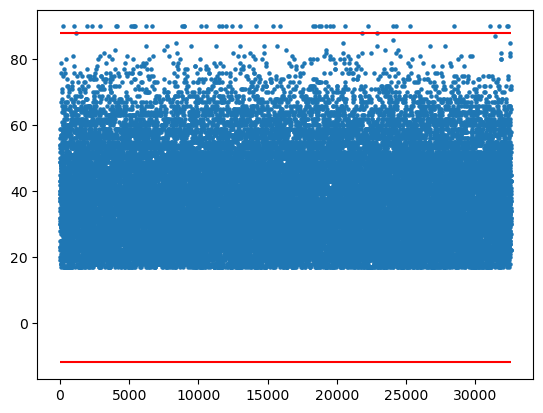

```python
# побудова графіку розкиду значень ряду даних Age, на якому червоні лінії - параметри a і b
plt.scatter(df_adult.index, df_adult['Age'], s = 5)
plt.hlines(a, xmin=df_adult.index[0], xmax= df_adult.index[-1], color = 'r')
plt.hlines(b, xmin=df_adult.index[0], xmax= df_adult.index[-1], color = 'r')
```

Аномальні значення за графіком: нижче за -12 та вище за 88.  
Враховуючи те, що цей ряд даних містить значення віку людей, аномальних даних не виявлено.

```python
#розрахунок меж діапазону [a; b] для ряду даних Fnlwgt, виведення значень a і b
t = df_adult.Fnlwgt.quantile((0.25, 0.75)).to_numpy()
a = t[0] - k * (t[1] - t[0])
b = t[1] + k * (t[1] - t[0])
print(a, b)
```

```
-120621.0 475499.0
```

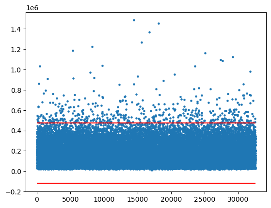

```python
# побудова графіку розкиду значень ряду даних Fnlwgt, на якому червоні лінії - параметри a і b
plt.scatter(df_adult.index, df_adult['Fnlwgt'], s = 5)
plt.hlines(a, xmin=df_adult.index[0], xmax= df_adult.index[-1], color = 'r')
plt.hlines(b, xmin=df_adult.index[0], xmax= df_adult.index[-1], color = 'r')
```

Аномальні значення за графіком: нижче за -120621 та вище за 475499.  
Враховуючи те, що цей ряд даних містить кількість людей, які мають такі ж характеристики, що і окрема людина зі списку, аномальних даних не виявлено.

```python
#розрахунок меж діапазону [a; b] для ряду даних Education_num, виведення значень a і b
t = df_adult.Education_num.quantile((0.25, 0.75)).to_numpy()
a = t[0] - k * (t[1] - t[0])
b = t[1] + k * (t[1] - t[0])
print(a, b)
```

```
3.0 18.0
```

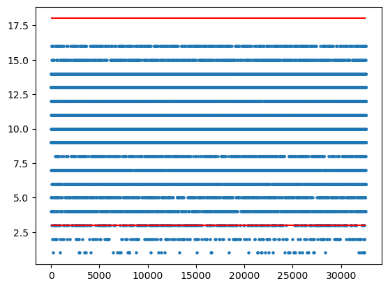

```python
# побудова графіку розкиду значень ряду даних Education_num, на якому червоні лінії - параметри a і b
plt.scatter(df_adult.index, df_adult['Education_num'], s = 5)
plt.hlines(a, xmin=df_adult.index[0], xmax= df_adult.index[-1], color = 'r')
plt.hlines(b, xmin=df_adult.index[0], xmax= df_adult.index[-1], color = 'r')
```

Аномальні значення за графіком: нижче за 3 та вище за 18.  
Цей ряд даних містить номери, еквівалентні кожному з 16 рівнів освіти. Отже, кожна особа може мати будь-який з них, і аномальних даних у цьому ряді не існує.

```python
#розрахунок меж діапазону [a; b] для ряду даних Capital_gain, виведення значень a і b
t = df_adult.Capital_gain.quantile((0.25, 0.75)).to_numpy()
a = t[0] - k * (t[1] - t[0])
b = t[1] + k * (t[1] - t[0])
print(a, b)
```

```
0.0 0.0
```

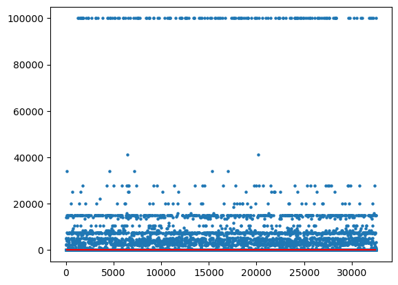

```python
# побудова графіку розкиду значень ряду даних Capital_gain, на якому червоні лінії - параметри a і b
plt.scatter(df_adult.index, df_adult['Capital_gain'], s = 5)
plt.hlines(a, xmin=df_adult.index[0], xmax= df_adult.index[-1], color = 'r')
plt.hlines(b, xmin=df_adult.index[0], xmax= df_adult.index[-1], color = 'r')
```

Аномальні значення за графіком розраховані з помилкою: межа діапазону починається та закінчується нулем.  
Цей ряд даних містить інформацію про приріст капіталу: більшість має дохід у межах від 0 до 20000, але існують і достатньо багаті, чий приріст складає близько 100000. Ці значення не є аномальними.

```python
#розрахунок меж діапазону [a; b] для ряду даних Capital_loss, виведення значень a і b
t = df_adult.Capital_loss.quantile((0.25, 0.75)).to_numpy()
a = t[0] - k * (t[1] - t[0])
b = t[1] + k * (t[1] - t[0])
print(a, b)
```

```
0.0 0.0
```

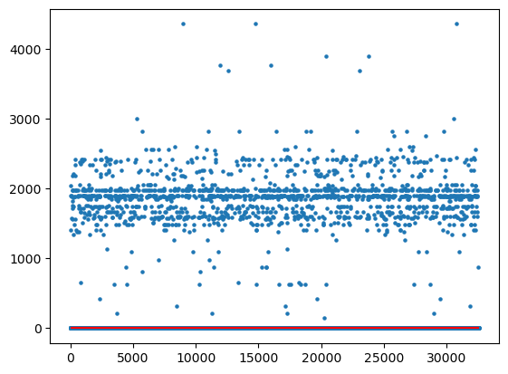

```python
# побудова графіку розкиду значень ряду даних Capital_loss, на якому червоні лінії - параметри a і b
plt.scatter(df_adult.index, df_adult['Capital_loss'], s = 5)
plt.hlines(a, xmin=df_adult.index[0], xmax= df_adult.index[-1], color = 'r')
plt.hlines(b, xmin=df_adult.index[0], xmax= df_adult.index[-1], color = 'r')
```

```python
#розрахунок меж діапазону [a; b] для ряду даних Hours_per_week, виведення значень a і b
t = df_adult.Hours_per_week.quantile((0.25, 0.75)).to_numpy()
a = t[0] - k * (t[1] - t[0])
b = t[1] + k * (t[1] - t[0])
print(a, b)
```

```
30.0 55.0
```

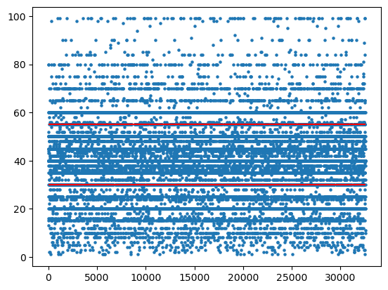

```python
# побудова графіку розкиду значень ряду даних Hours_per_week, на якому червоні лінії - параметри a і b
plt.scatter(df_adult.index, df_adult['Hours_per_week'], s = 5)
plt.hlines(a, xmin=df_adult.index[0], xmax= df_adult.index[-1], color = 'r')
plt.hlines(b, xmin=df_adult.index[0], xmax= df_adult.index[-1], color = 'r')
```

**7. Якщо у наборі даних є пропуски, некоректні або аномальні значення, видаляємо або заповнюємо їх модою (для якісних ознак) та середнім значенням (для кількісних ознак).**

Пропусків у наборі даних знайдено не було, проте існують некоретні значення: у деяких рядках даних присутні "?" замість дозволених значень, а у рядку Hours_per_week є аномалії.

```python
#у рядку даних Hours_per_week замінюємо значення >72 та <5 на NaN
df_adult['Hours_per_week'].where(df_adult['Hours_per_week'] < 72, inplace=True)
df_adult['Hours_per_week'].where(df_adult['Hours_per_week'] > 5, inplace=True)
df_adult.replace(' ?', np.nan, inplace=True) #усі "?" у рядках даних замінюємо на NaN
df_adult.isnull().sum() #виводимо кількість порожніх значень
```

```
Age                  0
Workclass         1836
Fnlwgt               0
Education            0
Education_num        0
Marital_status       0
Occupation        1843
Relationship         0
Race                 0
Sex                  0
Capital_gain         0
Capital_loss         0
Hours_per_week     703
Native_country     583
Gross_income         0
dtype: int64
```

```python
#відображаємо моду для трьох рядків з якісною ознакою
display(df_adult[['Workclass', 'Occupation', 'Native_country']].mode())
#відображаємо середнє значення рядка з кількісною ознакою
display(df_adult['Hours_per_week'].mean())
```

|  | Workclass | Occupation | Native_country |
| --- | --- | --- | --- |
| 0 | Private | Prof-specialty | United-States |

```
40.00508506497583
```

```python
#заповнюємо порожні значення рядків з якісним типом даних модами цих рядків, а рядка з кількісним типом даних - сер. значенням
df_adult.replace({'Workclass': {np.nan: df_adult['Workclass'].mode()}},inplace=True)
df_adult.replace({'Occupation': {np.nan: df_adult['Occupation'].mode()}},inplace=True)
df_adult.replace({'Native_country': {np.nan: df_adult['Native_country'].mode()}},inplace=True)
df_adult.replace({'Hours_per_week': {np.nan: df_adult['Hours_per_week'].mean()}},inplace=True)
df_adult.isnull().sum() #перевіряємо відсутність порожніх значень
```

```
Age               0
Workclass         0
Fnlwgt            0
Education         0
Education_num     0
Marital_status    0
Occupation        0
Relationship      0
Race              0
Sex               0
Capital_gain      0
Capital_loss      0
Hours_per_week    0
Native_country    0
Gross_income      0
dtype: int64
```

**8. Виконуємо перетворення якісних ознак методом бінаризації та перекодування значень ознаки в числа.**

```python
#виконуємо бінаризацію якісних значень та виводимо набір даних зі зміненими рядками
df_adult = pd.get_dummies(df_adult, columns=['Workclass', 'Education', 'Marital_status', 'Occupation', 'Relationship', 'Race', 'Sex', 'Native_country', 'Gross_income'], prefix_sep='', prefix='')
df_adult
```

|  | Age | Fnlwgt | Education_num | Capital_gain | Capital_loss | Hours_per_week | Federal-gov | Local-gov | Never-worked | Private | ... | Scotland | South | Taiwan | Thailand | Trinadad&Tobago | United-States | Vietnam | Yugoslavia | <=50K | >50K |
| --- | --- | --- | --- | --- | --- | --- | --- | --- | --- | --- | --- | --- | --- | --- | --- | --- | --- | --- | --- | --- | --- |
| 1 | 39 | 77516 | 13 | 2174 | 0 | 40.0 | 0 | 0 | 0 | 0 | ... | 0 | 0 | 0 | 0 | 0 | 1 | 0 | 0 | 1 | 0 |
| 2 | 50 | 83311 | 13 | 0 | 0 | 13.0 | 0 | 0 | 0 | 0 | ... | 0 | 0 | 0 | 0 | 0 | 1 | 0 | 0 | 1 | 0 |
| 3 | 38 | 215646 | 9 | 0 | 0 | 40.0 | 0 | 0 | 0 | 1 | ... | 0 | 0 | 0 | 0 | 0 | 1 | 0 | 0 | 1 | 0 |
| 4 | 53 | 234721 | 7 | 0 | 0 | 40.0 | 0 | 0 | 0 | 1 | ... | 0 | 0 | 0 | 0 | 0 | 1 | 0 | 0 | 1 | 0 |
| 5 | 28 | 338409 | 13 | 0 | 0 | 40.0 | 0 | 0 | 0 | 1 | ... | 0 | 0 | 0 | 0 | 0 | 0 | 0 | 0 | 1 | 0 |
| ... | ... | ... | ... | ... | ... | ... | ... | ... | ... | ... | ... | ... | ... | ... | ... | ... | ... | ... | ... | ... | ... |
| 32557 | 27 | 257302 | 12 | 0 | 0 | 38.0 | 0 | 0 | 0 | 1 | ... | 0 | 0 | 0 | 0 | 0 | 1 | 0 | 0 | 1 | 0 |
| 32558 | 40 | 154374 | 9 | 0 | 0 | 40.0 | 0 | 0 | 0 | 1 | ... | 0 | 0 | 0 | 0 | 0 | 1 | 0 | 0 | 0 | 1 |
| 32559 | 58 | 151910 | 9 | 0 | 0 | 40.0 | 0 | 0 | 0 | 1 | ... | 0 | 0 | 0 | 0 | 0 | 1 | 0 | 0 | 1 | 0 |
| 32560 | 22 | 201490 | 9 | 0 | 0 | 20.0 | 0 | 0 | 0 | 1 | ... | 0 | 0 | 0 | 0 | 0 | 1 | 0 | 0 | 1 | 0 |
| 32561 | 52 | 287927 | 9 | 15024 | 0 | 40.0 | 0 | 0 | 0 | 0 | ... | 0 | 0 | 0 | 0 | 0 | 1 | 0 | 0 | 0 | 1 |

32561 rows × 107 columns

Для стандартизації кількісних ознак використовуємо формулу:

$x^*_i = (x_i - x_{a})/S,$  
де $x_{a}$ - середнє значення ознаки $x_i$,  
$S$ - середньоквадратичне відхилення ознаки$.

Для нормалізації кількісних ознак використовуємо формулу:

$x^*_i = (x_i - x_{min})/(x_{max} - x_{min}),$  
де $x_{min}$ - мінімальне значення ознаки $x_i$,  
$x_{max}$ - максимальне значення ознаки $x_i$.

```python
#нормалізуємо кількісні ознаки за формулою та виводимо набір даних
num = ['Age', 'Fnlwgt', 'Education_num', 'Capital_gain', 'Capital_loss', 'Hours_per_week']
df_adult[num] = (df_adult[num] - df_adult[num].min())/(df_adult[num].max() - df_adult[num].min())
df_adult
```

|  | Age | Fnlwgt | Education_num | Capital_gain | Capital_loss | Hours_per_week | Federal-gov | Local-gov | Never-worked | Private | ... | Scotland | South | Taiwan | Thailand | Trinadad&Tobago | United-States | Vietnam | Yugoslavia | <=50K | >50K |
| --- | --- | --- | --- | --- | --- | --- | --- | --- | --- | --- | --- | --- | --- | --- | --- | --- | --- | --- | --- | --- | --- |
| 1 | 0.301370 | 0.044302 | 0.800000 | 0.021740 | 0.0 | 0.531250 | 0 | 0 | 0 | 0 | ... | 0 | 0 | 0 | 0 | 0 | 1 | 0 | 0 | 1 | 0 |
| 2 | 0.452055 | 0.048238 | 0.800000 | 0.000000 | 0.0 | 0.109375 | 0 | 0 | 0 | 0 | ... | 0 | 0 | 0 | 0 | 0 | 1 | 0 | 0 | 1 | 0 |
| 3 | 0.287671 | 0.138113 | 0.533333 | 0.000000 | 0.0 | 0.531250 | 0 | 0 | 0 | 1 | ... | 0 | 0 | 0 | 0 | 0 | 1 | 0 | 0 | 1 | 0 |
| 4 | 0.493151 | 0.151068 | 0.400000 | 0.000000 | 0.0 | 0.531250 | 0 | 0 | 0 | 1 | ... | 0 | 0 | 0 | 0 | 0 | 1 | 0 | 0 | 1 | 0 |
| 5 | 0.150685 | 0.221488 | 0.800000 | 0.000000 | 0.0 | 0.531250 | 0 | 0 | 0 | 1 | ... | 0 | 0 | 0 | 0 | 0 | 0 | 0 | 0 | 1 | 0 |
| ... | ... | ... | ... | ... | ... | ... | ... | ... | ... | ... | ... | ... | ... | ... | ... | ... | ... | ... | ... | ... | ... |
| 32557 | 0.136986 | 0.166404 | 0.733333 | 0.000000 | 0.0 | 0.500000 | 0 | 0 | 0 | 1 | ... | 0 | 0 | 0 | 0 | 0 | 1 | 0 | 0 | 1 | 0 |
| 32558 | 0.315068 | 0.096500 | 0.533333 | 0.000000 | 0.0 | 0.531250 | 0 | 0 | 0 | 1 | ... | 0 | 0 | 0 | 0 | 0 | 1 | 0 | 0 | 0 | 1 |
| 32559 | 0.561644 | 0.094827 | 0.533333 | 0.000000 | 0.0 | 0.531250 | 0 | 0 | 0 | 1 | ... | 0 | 0 | 0 | 0 | 0 | 1 | 0 | 0 | 1 | 0 |
| 32560 | 0.068493 | 0.128499 | 0.533333 | 0.000000 | 0.0 | 0.218750 | 0 | 0 | 0 | 1 | ... | 0 | 0 | 0 | 0 | 0 | 1 | 0 | 0 | 1 | 0 |
| 32561 | 0.479452 | 0.187203 | 0.533333 | 0.150242 | 0.0 | 0.531250 | 0 | 0 | 0 | 0 | ... | 0 | 0 | 0 | 0 | 0 | 1 | 0 | 0 | 0 | 1 |

32561 rows × 107 columns

**10. Вилучаємо з набору даних ознаки, які однозначно не можуть бути корисні в подальшому або дублюють інформацію інших.**

```python
#вилучаємо рядок даних Education_num, адже вже є рядок даних Education
df_adult.drop(['Education_num'], axis='columns', inplace=True)
df_adult
```

|  | Age | Fnlwgt | Capital_gain | Capital_loss | Hours_per_week | Federal-gov | Local-gov | Never-worked | Private | Self-emp-inc | ... | Scotland | South | Taiwan | Thailand | Trinadad&Tobago | United-States | Vietnam | Yugoslavia | <=50K | >50K |
| --- | --- | --- | --- | --- | --- | --- | --- | --- | --- | --- | --- | --- | --- | --- | --- | --- | --- | --- | --- | --- | --- |
| 1 | 0.301370 | 0.044302 | 0.021740 | 0.0 | 0.531250 | 0 | 0 | 0 | 0 | 0 | ... | 0 | 0 | 0 | 0 | 0 | 1 | 0 | 0 | 1 | 0 |
| 2 | 0.452055 | 0.048238 | 0.000000 | 0.0 | 0.109375 | 0 | 0 | 0 | 0 | 0 | ... | 0 | 0 | 0 | 0 | 0 | 1 | 0 | 0 | 1 | 0 |
| 3 | 0.287671 | 0.138113 | 0.000000 | 0.0 | 0.531250 | 0 | 0 | 0 | 1 | 0 | ... | 0 | 0 | 0 | 0 | 0 | 1 | 0 | 0 | 1 | 0 |
| 4 | 0.493151 | 0.151068 | 0.000000 | 0.0 | 0.531250 | 0 | 0 | 0 | 1 | 0 | ... | 0 | 0 | 0 | 0 | 0 | 1 | 0 | 0 | 1 | 0 |
| 5 | 0.150685 | 0.221488 | 0.000000 | 0.0 | 0.531250 | 0 | 0 | 0 | 1 | 0 | ... | 0 | 0 | 0 | 0 | 0 | 0 | 0 | 0 | 1 | 0 |
| ... | ... | ... | ... | ... | ... | ... | ... | ... | ... | ... | ... | ... | ... | ... | ... | ... | ... | ... | ... | ... | ... |
| 32557 | 0.136986 | 0.166404 | 0.000000 | 0.0 | 0.500000 | 0 | 0 | 0 | 1 | 0 | ... | 0 | 0 | 0 | 0 | 0 | 1 | 0 | 0 | 1 | 0 |
| 32558 | 0.315068 | 0.096500 | 0.000000 | 0.0 | 0.531250 | 0 | 0 | 0 | 1 | 0 | ... | 0 | 0 | 0 | 0 | 0 | 1 | 0 | 0 | 0 | 1 |
| 32559 | 0.561644 | 0.094827 | 0.000000 | 0.0 | 0.531250 | 0 | 0 | 0 | 1 | 0 | ... | 0 | 0 | 0 | 0 | 0 | 1 | 0 | 0 | 1 | 0 |
| 32560 | 0.068493 | 0.128499 | 0.000000 | 0.0 | 0.218750 | 0 | 0 | 0 | 1 | 0 | ... | 0 | 0 | 0 | 0 | 0 | 1 | 0 | 0 | 1 | 0 |
| 32561 | 0.479452 | 0.187203 | 0.150242 | 0.0 | 0.531250 | 0 | 0 | 0 | 0 | 1 | ... | 0 | 0 | 0 | 0 | 0 | 1 | 0 | 0 | 0 | 1 |

32561 rows × 106 columns

```python
df_adult.drop_duplicates(inplace=True) #вилучаємо рядки, що повторюються
```

```python
df_adult.to_csv('adultC.csv')
```